# A Regression Analysis of Hate Crime

Author

Jack Flugstad, Harley Nguyen

Published

May 14, 2026

## Abstract

Hate crime is a global issue, but is particularly relevant in the United States. A hate crime is defined as an illegal action towards an individual based on bias against the victim’s race, color, religion, national origin, sex, disability, or actual or perceived sexual orientation (FBI, 2026). In effect, there is an element of prejudice that motivates the illegal action. This analysis seeks to determine if there is a correlation between hate crime and demographic patterns like unemployment, income, inequality, education, political stance, and race. To do so, the analysis aims to generate a multiple regression model to estimate the average hate crimes per 100,000 people by state using variables surrounding unemployment, income, inequality, education, political stance, and race. To evaluate the potential correlation, we analyzed hate crime data from the fivethirtyeight github repository joined with racial demographic data from the CORGIS online database and voting data from the Harvard Dataverse repository. The data aggregates multiple socioeconomic variables by state, summing to a total of 49 observations. We fit several regression models based on gamma regression. The final gamma model suggests that hate crimes vary positively with Gini index and share of the population with a high school degree, and negatively with the share of Black people in the population. These results should be interpreted cautiously because of the small sample size, but are corroborated by the literature and economic schools of thought around hate crimes.

## Introduction

Hate crimes are a significant point of conflict in the United States. 2023 saw the highest number of reported hate crimes ever, at 11,862, and 2024 the second highest at 11,679 reported attacks. The FBI identifies hate crimes as violent or property-damaging criminal activity “motivated in whole or in part by an offender’s bias against a race, religion, disability, sexual orientation, ethnicity, gender or gender identity.” (Fatherree, 2025). The bias component is the key part of this definition that differentiates hate crimes and other forms of illegal activity; hate crime is based on a criminal’s prejudice against their victims. In 2024, 53.2% of hate crime in the United States was based on race, ethnicity, or ancestry, while 23.5% was motivated by religion. Furthermore, sexual orientation accounted for 17.2%, gender identity for 3.9%, disability for 1.3%, and gender for 0.9% (U.S. Department of Justice, 2025). Race is the leading motivator for hate crimes in the United States, naturally leading to the question of how racial demographics of an area are correlated with the rate of hate crime in that area. Other socioeconomic and political predictors such as political party affiliation and inequality are also relatively unexplored. Therefore, our analysis looks to construct a model to predict hate crime rates using political, socioeconomic, and demographic dependent variables in the United States. In turn, the goal of this model is to provide insight into how socioeconomic factors affect hate crimes, with the larger aim of mitigating hate crime.

## Materials and Methods

### Datasets

The primary dataset used in this analysis was the Hate Crimes dataset from the fivethirtyeight github data repository (Fivethirtyeight). The data set was constructed using data from the Kaiser Family Foundation, the United States Census Bureau, the United States Election Project, the Southern Poverty Law Center, and the Federal Bureau of Investigation. The Kaiser Family Foundation is a non-profit independent source for health policy research (KFF), while the Census Bureau aggregates thousands of socioeconomic variables to gather data from the United States population (United States Census Bureau, 2024). The United States Election project contains election data compiled by Dr. Michael P. McDonald, University of Florida Professor of Political Science and Harvard Post-Doctoral Fellow (McDonald). The Southern Poverty Law Center is a racial equality initiative founded in 1971 that provides demographic data for the Hate Crimes dataset (SPLC). Finally, the FBI records data on hate crimes from the Uniform Crime Reporting Program (U.S. Department of Justice, 2025). fivethirtyeight compiled data from these sources to create the Hate Crimes dataset, which breaks hate crime and other socioeconomic variables down by state. Variables include state, median household income (2016), seasonally adjusted unemployment rate (2016), share of population that lives in metropolitan areas (2015), share of adults 25 and older with a high school degree (2009), share of the population that are not United States citizens (2015), share of white residents who are living in poverty (2015), gini index (2015), share of the population that is not white (2015), share of U.S. presidential voters who voted for Donald Trump (2016), hate crimes per 100,000 population (Southern Poverty Law Center, Nov. 9-18, 2016), and average annual hate crimes per 100,000 population (FBI, 2010-2015). Outside of state, which is categorical, the remaining 11 variables are numerical and continuous.

The Hate Crime dataset was supplemented with two other datasets. The first was the State Demographics dataset from the online CORGIS database (Whitcomb et al., 2021). CORGIS stands for the Collection of Really Great, Interesting, Situated Datasets, and contains around 40 real-world pre-cleaned and tidy data sets across a variety of topics, from advertising to airlines. The State Demographics dataset was ideal for our analysis because it aggregates race variables from 2015 - 2019 by state, making for easy joining with the Hate Crime dataset. Notable variables for our analysis in the State Demographics dataset include population percentages of Black, Asian, and Hispanic people for each state.

We also supplemented the Hate Crime Dataset with the U.S. President dataset from the Harvard Dataverse data repository, part of the Harvard online library (MIT Election Data and Science Lab, 2017). This dataset is organized by year, recording votes for each presidential candidate by state by year from 1976 - 2020. We used this dataset to supplement the existing voting data in the Hate Crimes dataset, focusing on the 2012 presidential election as this election matches the time frame of the Hate Crimes data. It contains various political party and voting variables, but we focused specifically on the counts of votes for the Republican and Democratic nominees and the total number of votes in order to classify each state as a red or blue state in the 2012 election, a predictor in our analysis.

Centered around the Hate Crimes dataset, we created a composite dataset. The final dataset contained 49 observations, each corresponding to a state. Because we are focused on states, Washington D.C. was removed from the analysis. Additionally, Hawaii had no recorded data for hate crimes, and because of the small sample size, we chose not to impute the value for fear of getting an unreasonable value and instead removed Hawaii from the analysis. The unified state-level dataset contains socioeconomic, demographic, and political predictors. It contains the continuous variables median household income (2016), seasonally adjusted unemployment rate (2016), share of population that lives in metropolitan areas (2015), share of adults 25 and older with a high school degree (2009), share of the population that are not United States citizens (2015), share of white residents who are living in poverty (2015), gini index (2015), share of the population that is not white (2015), share of U.S. presidential voters who voted for Donald Trump (2016), hate crimes per 100,000 population (Southern Poverty Law Center, Nov. 9-18, 2016), and average annual hate crimes per 100,000 population (FBI, 2010-2015) from the original Hate Crimes dataset. Calculated from the State Demographics dataset, the continuous race variables black share, asian share, hispanic share, and white non hispanic share were added to the state level observations. Finally, democratic share, republican share, and party that each state swung for were calculated from the U.S. President dataset. Five number summaries and mean value of some key variables are detailed in Figure 1.

### Data Construction

```r
library(dplyr)
library(tidyr)
library(stringr)
library(ggplot2)
library(scales)
library(fitdistrplus)
library(goftest)
library(gofgamma)
library(stargazer)
library(knitr)
library(kableExtra)
theme_set(theme_bw(base_size = 12, base_family = "Times New Roman"))
```

```r
hate     <- read.csv("hate_crimes.csv")
demo     <- read.csv("state_demographics.csv")
election <- read.csv("1976-2020-president.csv")
```

```r
#################################################
# 1. Select race variables from CORGIS
#################################################

demo_sub <- demo %>%
  dplyr::select(
    State,
    Ethnicities.Black.Alone,
    Ethnicities.Hispanic.or.Latino,

    Ethnicities.Asian.Alone,
    Ethnicities.White.Alone..not.Hispanic.or.Latino
  ) %>%
  rename(
    state = State,
    black_share = Ethnicities.Black.Alone,
    hispanic_share = Ethnicities.Hispanic.or.Latino,
    asian_share = Ethnicities.Asian.Alone,
    white_non_hispanic_share = Ethnicities.White.Alone..not.Hispanic.or.Latino
  )

#################################################
# 2. Clean 2012 presidential election data
#################################################

election_2012 <- election %>%
  filter(year == 2012) %>%
  mutate(
    state = str_to_title(str_to_lower(state))
  )

election_2012_wide <- election_2012 %>%
  filter(party_simplified %in% c("DEMOCRAT", "REPUBLICAN")) %>%
  group_by(state, party_simplified) %>%
  summarise(
    votes = sum(candidatevotes, na.rm = TRUE),
    totalvotes = max(totalvotes, na.rm = TRUE),
    .groups = "drop"
  ) %>%
  mutate(vote_share = votes / totalvotes) %>%
  dplyr::select(state, party_simplified, vote_share) %>%
  pivot_wider(
    names_from = party_simplified,
    values_from = vote_share
  )

election_2012_clean <- election_2012_wide %>%
  mutate(
    political_party_2012 = ifelse(
      REPUBLICAN > DEMOCRAT,
      "Republican (Romney)",
      "Democratic (Obama)"
    )
  ) %>%
  dplyr::select(
    state,
    dem_share_2012 = DEMOCRAT,
    rep_share_2012 = REPUBLICAN,
    political_party_2012
  )

#################################################
# 3. Merge datasets
#################################################

merged_data <- hate %>%
  left_join(demo_sub, by = "state") %>%
  left_join(election_2012_clean, by = "state")

#################################################
# 4. Initial cleaning
# Remove DC because project focuses on states.
# Check rows missing dependent variable.
#################################################
merged_clean <- merged_data %>%
  filter(
    state != "District of Columbia",
    !is.na(avg_hatecrimes_per_100k_fbi),
    !is.na(median_household_income),
    !is.na(share_unemployed_seasonal),
    !is.na(gini_index),
    !is.na(share_population_with_high_school_degree),
    !is.na(black_share),
    !is.na(hispanic_share),
    !is.na(asian_share),
    !is.na(political_party_2012)
  )
```

### Figure 1. Summary Statistics

Five-number summaries and mean values of key variables across 49 state-level observations.

```r
key_vars <- merged_clean |>
  dplyr::select(
    `Hate Crimes per 100k`   = avg_hatecrimes_per_100k_fbi,
    `Median HH Income`       = median_household_income,
    `Unemployment Share`     = share_unemployed_seasonal,
    `Metro Population Share` = share_population_in_metro_areas,
    `Gini Index`             = gini_index,
    `HS Degree Share`        = share_population_with_high_school_degree,
    `Non-Citizen Share`      = share_non_citizen,
    `White Poverty Share`    = share_white_poverty,
    `Non-White Share`        = share_non_white,
    `Trump Voter Share`      = share_voters_voted_trump,
    `Black Share`            = black_share,
    `Hispanic Share`         = hispanic_share,
    `Asian Share`            = asian_share,
    `White Non-Hispanic Share` = white_non_hispanic_share,
    `Democratic Share 2012`  = dem_share_2012,
    `Republican Share 2012`  = rep_share_2012
  )

summary_tbl <- as.data.frame(t(sapply(key_vars, function(x) {
  c(
    Mean   = round(mean(x, na.rm = TRUE), 3),
    Min    = round(min(x, na.rm = TRUE), 3),
    Q1     = round(quantile(x, 0.25, na.rm = TRUE), 3),
    Median = round(median(x, na.rm = TRUE), 3),
    Mean   = round(mean(x, na.rm = TRUE), 3),
    Q3     = round(quantile(x, 0.75, na.rm = TRUE), 3),
    Max    = round(max(x, na.rm = TRUE), 3)
  )
})))

summary_tbl %>%
  kbl(caption = "Figure 1. Five-Number Summary of Key Variables") %>%
  kable_styling(full_width = FALSE, bootstrap_options = c("striped", "hover"))
```

|  | Mean | Min | Q1.25% | Median | Mean | Q3.75% | Max |
| --- | --- | --- | --- | --- | --- | --- | --- |
| Hate Crimes per 100k | 2.192 | 0.267 | 1.283 | 1.937 | 2.192 | 3.136 | 4.802 |
| Median HH Income | 54630.694 | 35521.000 | 48060.000 | 54310.000 | 54630.694 | 60487.000 | 76165.000 |
| Unemployment Share | 0.050 | 0.028 | 0.042 | 0.051 | 0.050 | 0.057 | 0.073 |
| Metro Population Share | 0.745 | 0.310 | 0.630 | 0.790 | 0.745 | 0.890 | 1.000 |
| Gini Index | 0.453 | 0.419 | 0.440 | 0.454 | 0.453 | 0.466 | 0.499 |
| HS Degree Share | 0.868 | 0.799 | 0.839 | 0.874 | 0.868 | 0.898 | 0.918 |
| Non-Citizen Share | 0.053 | 0.010 | 0.030 | 0.040 | 0.053 | 0.078 | 0.130 |
| White Poverty Share | 0.093 | 0.050 | 0.080 | 0.090 | 0.093 | 0.100 | 0.170 |
| Non-White Share | 0.299 | 0.060 | 0.190 | 0.270 | 0.299 | 0.420 | 0.620 |
| Trump Voter Share | 0.503 | 0.330 | 0.420 | 0.500 | 0.503 | 0.580 | 0.700 |
| Black Share | 11.373 | 0.600 | 3.700 | 8.500 | 11.373 | 15.700 | 37.800 |
| Hispanic Share | 12.298 | 1.700 | 5.300 | 9.800 | 12.298 | 14.400 | 49.300 |
| Asian Share | 3.882 | 0.800 | 1.800 | 3.000 | 3.882 | 5.000 | 15.500 |
| White Non-Hispanic Share | 69.224 | 36.500 | 60.200 | 71.400 | 69.224 | 79.100 | 93.000 |
| Democratic Share 2012 | 0.477 | 0.247 | 0.399 | 0.500 | 0.477 | 0.542 | 0.666 |
| Republican Share 2012 | 0.502 | 0.310 | 0.421 | 0.491 | 0.502 | 0.579 | 0.728 |

Figure 1: Figure 1. Five-Number Summary of Key Variables

## Statistical Analysis — Exploratory Data Analysis

Our analysis began with an exploration of the outcome variable, average hate crimes per 100,000 people for each state as reported by the FBI. The variable is right skewed, with most states falling around 2 hate crimes per 100,000. There are other notable peaks around 0.5 hate crimes and 3 hate crimes. See Figure 2.

### Figure 2. Distribution of Average Hate Crimes

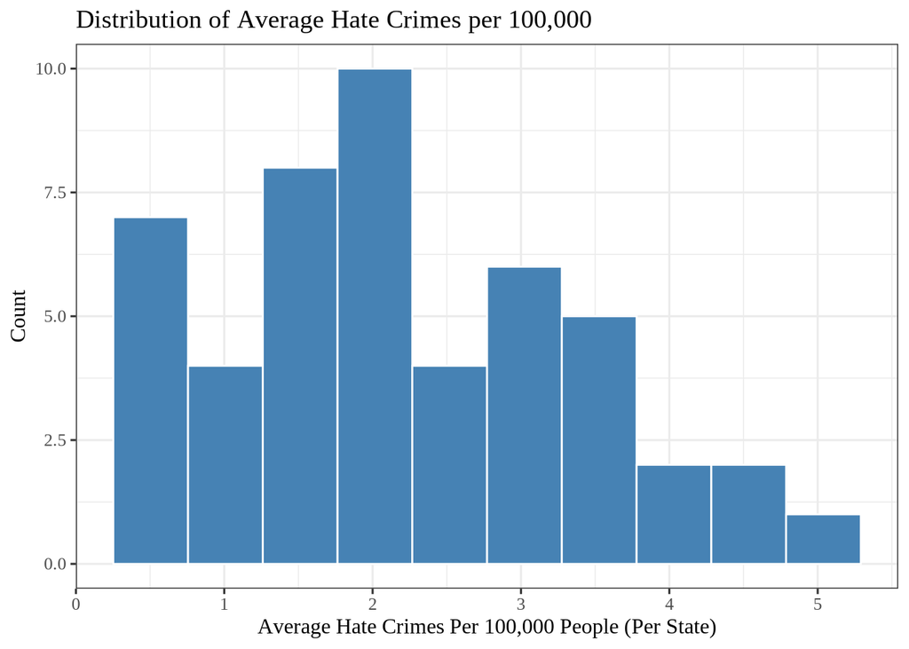

Figure 2

```r
merged_clean %>%
  ggplot(aes(x = avg_hatecrimes_per_100k_fbi)) +
  geom_histogram(bins = 10, fill = "steelblue", color = "white") +
  labs(
    title = "Distribution of Average Hate Crimes per 100,000",
    x     = "Average Hate Crimes Per 100,000 People (Per State)",
    y     = "Count"
  )
```

Next, our analysis moved to exploration of bivariate relationships. We broke our explanatory variables down into three categories: political, socioeconomic, and demographic. To explore the relationship between political views and hate crime, we visualized the distribution of hate crimes by state, and colored each state by the presidential candidate they voted for in the 2012 presidential election. See Figure 3.

### Figure 3. Hate Crime Rate by State and Political Party

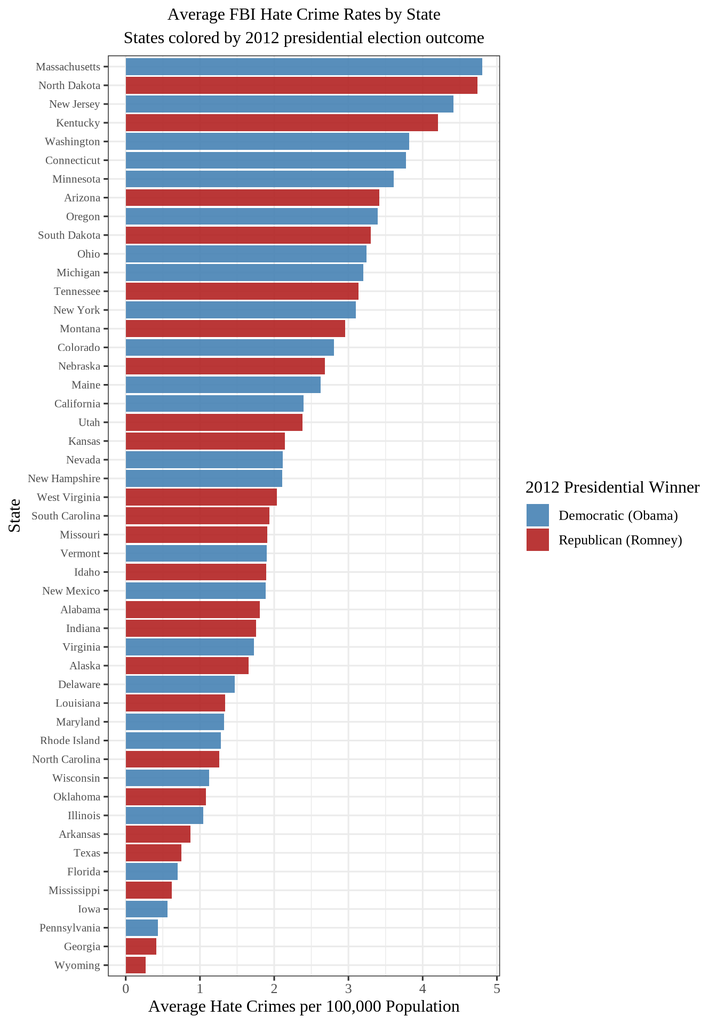

Figure 3

```r
ggplot(
  merged_clean,
  aes(
    x    = reorder(state, avg_hatecrimes_per_100k_fbi),
    y    = avg_hatecrimes_per_100k_fbi,
    fill = political_party_2012
  )
) +
  geom_col(alpha = 0.9) +
  coord_flip() +
  scale_fill_manual(
    values = c(
      "Democratic (Obama)"  = "steelblue",
      "Republican (Romney)" = "firebrick"
    )
  ) +
  labs(
    title    = "Average FBI Hate Crime Rates by State",
    subtitle = "States colored by 2012 presidential election outcome",
    x        = "State",
    y        = "Average Hate Crimes per 100,000 Population",
    fill     = "2012 Presidential Winner"
  ) +
  theme(
    plot.title    = element_text(hjust = 0.5, size = 12),
    plot.subtitle = element_text(hjust = 0.5, size = 12),
    axis.text.y   = element_text(size = 8)
  )
```

This plot shows that average FBI hate crime rates vary substantially across states. Massachusetts, North Dakota, New Jersey, and Kentucky appear near the higher end, while Wyoming, Georgia, and Pennsylvania appear near the lower end. Coloring states by 2012 presidential winner does not show a very clear political pattern, which suggests that political category alone may not explain much of the variation in hate crime rates. This motivates looking at broader socioeconomic and demographic predictors.

Next, we moved to visualizing socioeconomic predictors, namely gini index, share of population with a high school degree, median household income, and unemployment share per state. Because these are continuous predictors, we plotted each of them against hate crime rate and fit a regression line to explore any positive or negative correlation between each predictor and hate crime. See Figure 4.

### Figure 4. Socioeconomic Predictors vs. Hate Crime Rate

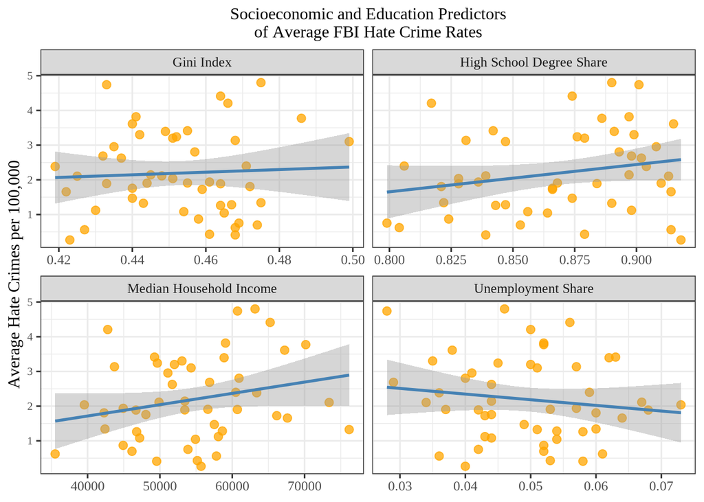

Figure 4

```r
socio_data <- merged_clean %>%
  dplyr::select(
    avg_hatecrimes_per_100k_fbi,
    median_household_income,
    share_unemployed_seasonal,
    gini_index,
    share_population_with_high_school_degree
  ) %>%
  pivot_longer(
    cols      = -avg_hatecrimes_per_100k_fbi,
    names_to  = "predictor",
    values_to = "value"
  ) %>%
  mutate(
    predictor = recode(
      predictor,
      "median_household_income"                  = "Median Household Income",
      "share_unemployed_seasonal"                = "Unemployment Share",
      "gini_index"                               = "Gini Index",
      "share_population_with_high_school_degree" = "High School Degree Share"
    )
  )

ggplot(socio_data,
       aes(x = value, y = avg_hatecrimes_per_100k_fbi)) +
  geom_point(color = "orange", size = 2.5, alpha = 0.75) +
  geom_smooth(method = "lm", se = TRUE, color = "steelblue") +
  facet_wrap(~ predictor, scales = "free_x") +
  labs(
    title = "Socioeconomic and Education Predictors\nof Average FBI Hate Crime Rates",
    x     = NULL,
    y     = "Average Hate Crimes per 100,000"
  ) +
  theme(
    plot.title = element_text(hjust = 0.5, size = 12),
    axis.text.y = element_text(size = 8)
  )
```

The faceted scatterplots show the bivariate relationships between hate crime rates and socioeconomic variables. Gini Index and high school degree share appear to have slight positive relationships with hate crime rates, while unemployment has a weak negative trend. Median household income also appears somewhat positively related. However, none of these plots shows an extremely strong standalone relationship, which suggests that hate crime rates are likely shaped by multiple predictors rather than one single factor.

### Figure 5. Racial Composition Across States

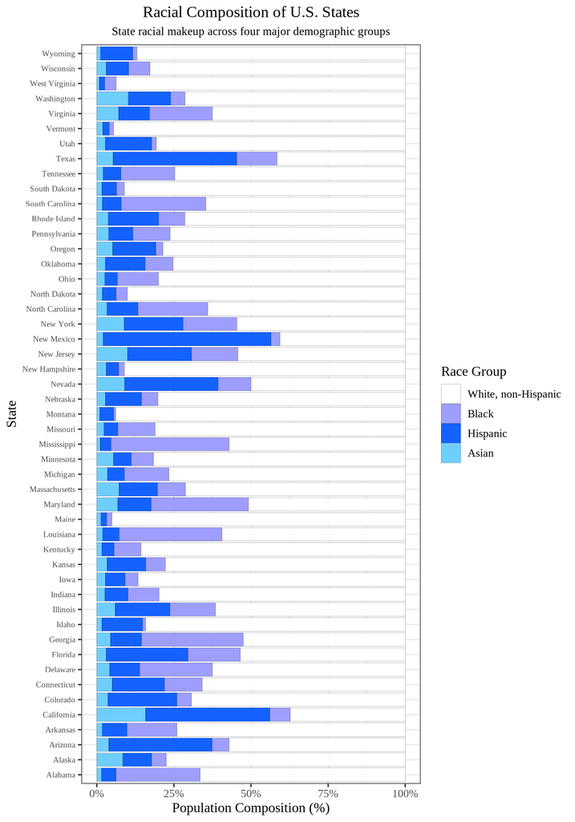

Figure 5

```r
race_state <- merged_clean %>%
  dplyr::select(
    state,
    white_non_hispanic_share,
    black_share,
    hispanic_share,
    asian_share
  ) %>%
  pivot_longer(
    cols      = c(white_non_hispanic_share, black_share, hispanic_share, asian_share),
    names_to  = "race_group",
    values_to = "share"
  ) %>%
  mutate(
    race_group = recode(
      race_group,
      "white_non_hispanic_share" = "White, non-Hispanic",
      "black_share"              = "Black",
      "hispanic_share"           = "Hispanic",
      "asian_share"              = "Asian"
    ),
    race_group = factor(
      race_group,
      levels = c("White, non-Hispanic", "Black", "Hispanic", "Asian")
    )
  )

ggplot(race_state, aes(x = state, y = share, fill = race_group)) +
  geom_col(position = "fill", alpha = 0.95, color = "black", linewidth = 0.05) +
  coord_flip() +
  scale_y_continuous(labels = scales::percent_format(scale = 100)) +
  scale_fill_manual(
    breaks = c("White, non-Hispanic", "Black", "Hispanic", "Asian"),
    values = c(
      "White, non-Hispanic" = "white",
      "Black"               = "#9999FF",
      "Hispanic"            = "#085AFF",
      "Asian"               = "#66CCFF"
    )
  ) +
  labs(
    title    = "Racial Composition of U.S. States",
    subtitle = "State racial makeup across four major demographic groups",
    x        = "State",
    y        = "Population Composition (%)",
    fill     = "Race Group"
  ) +
  theme(
    plot.title  = element_text(hjust = 0.5, size = 14),
    plot.subtitle = element_text(hjust = 0.5, size = 10),
    axis.text.y = element_text(size = 7)
  )
```

This visualization shows that racial composition varies meaningfully across states. Some states have much larger Black or Hispanic population shares, while Asian population shares are smaller overall but still vary by state. This supports our decision to include more specific racial composition variables instead of relying only on a broad “non-white share.” Since race composition differs strongly across states, it may help explain state-level differences in hate crime rates.

## Model Selection

The outcome variable is hate crimes per 100,000 people. To model the outcome, we chose a gamma distribution with estimated shape parameter of 2.817178 and estimated rate parameter of 1.285045. To verify the validity of a gamma distribution, several measures were taken. We began with a visual diagnostic. A theoretical gamma density distribution was overlaid across our data to see if the two matched. See Figure 6.

### Figure 6. Data Density vs. Theoretical Gamma Curve

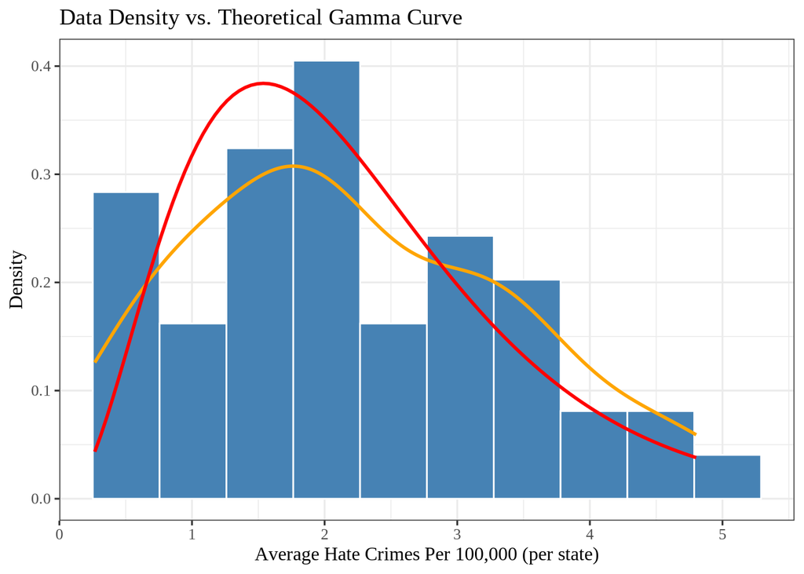

Figure 6

```r
merged_clean %>%
  ggplot(aes(x = avg_hatecrimes_per_100k_fbi)) +
  geom_histogram(
    aes(y = after_stat(density)),
    bins  = 10,
    fill  = "steelblue",
    color = "white"
  ) +
  geom_density(color = "orange", linewidth = 1) +
  stat_function(
    fun  = dgamma,
    args = list(
      shape = mean(merged_clean$avg_hatecrimes_per_100k_fbi)^2 /
              var(merged_clean$avg_hatecrimes_per_100k_fbi),
      rate  = mean(merged_clean$avg_hatecrimes_per_100k_fbi) /
              var(merged_clean$avg_hatecrimes_per_100k_fbi)
    ),
    color    = "red",
    linewidth = 1
  ) +
  labs(
    title = "Data Density vs. Theoretical Gamma Curve",
    x     = "Average Hate Crimes Per 100,000 (per state)",
    y     = "Density"
  )
```

The red line shows the simulated gamma distribution with the calculated shape and rate parameters, while the orange line shows the smooth density distribution of hate crimes. Finally, the bars are a histogram of hate crime data. From this plot, we observed that hate crimes are right skewed and roughly follow a gamma distribution. However, there are notable deviations from the theorized distribution, with the peak of the true data occurring at a higher value of hate crime than the theorized distribution, and a second smaller peak in the 3 hate crime region that sticks above the theorized distribution. It is important to note that our sample size of 49 is small, so the deviations from the theorized distribution may be influenced by sample size. With sample size in mind, we concluded that a gamma distribution was worth exploring further.

We employed several other visualization methods to explore the possibility of a gamma distribution. The first was a sample of randomly generated distributions using a potential gamma model fit to our data assuming that the data can be modeled by a gamma distribution. This model included predictors gini index, black share, and hispanic share. We then used this model to simulate 50 sample datasets and plot their density function. Each sample density function is in grey, while the true data is in black (Ford, 2022). See Figure 7.

### Figure 7. Simulated Gamma Distributions

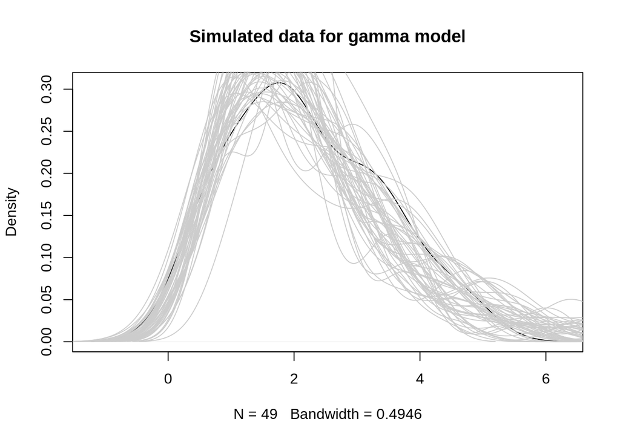

Figure 7

```r
mod1 <- glm(avg_hatecrimes_per_100k_fbi ~
    gini_index * black_share +
    hispanic_share, data = merged_clean,
          family = Gamma(link = "log"))





sims1 <- simulate(mod1, nsim = 50)
plot(density(merged_clean$avg_hatecrimes_per_100k_fbi),
     main = "Simulated data for gamma model")
for(i in 1:50)lines(density(sims1[[i]]), col="grey80")
```

From this plot, we observed that our distribution is within the theoretical variability of a gamma distribution, further supporting the idea that a gamma regression model could be a good fit for our data.

As a final visual check, we plotted a Cullen and Frey diagnostic plot. This measure plots our observed data as a blue dot, with various regions of the graph indicating different distributions. See Figure 8.

### Figure 8. Cullen and Frey Diagnostic

```
summary statistics
------
min:  0.2669408   max:  4.801899
median:  1.937083
mean:  2.192391
estimated sd:  1.196972
estimated skewness:  0.3955371
estimated kurtosis:  2.371178
```

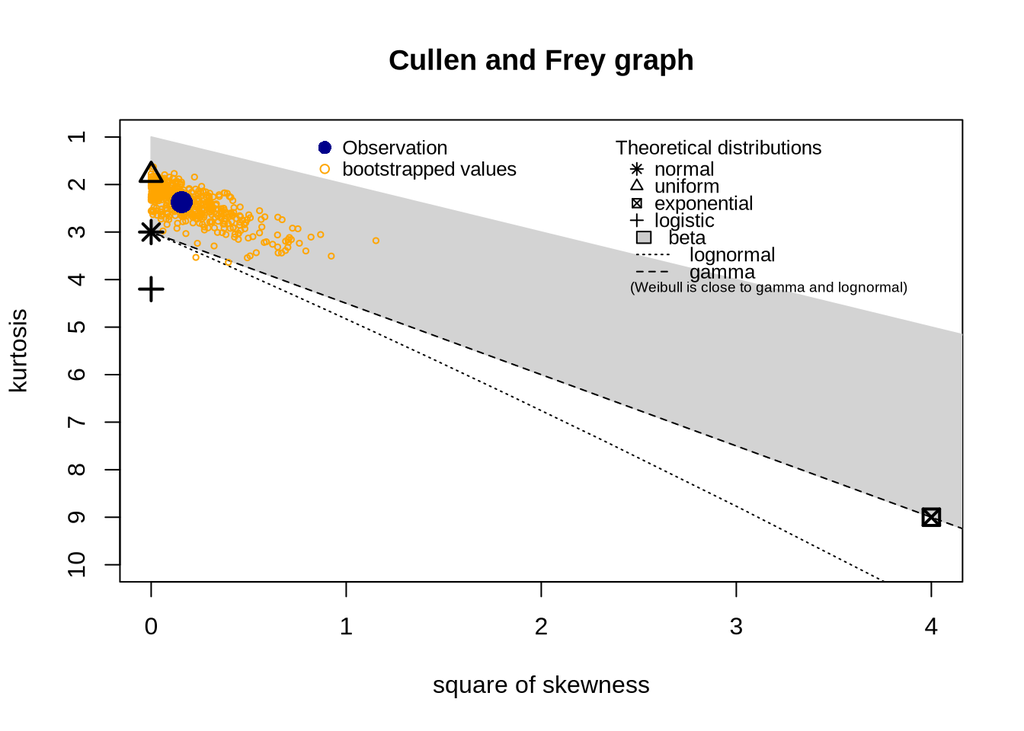

Figure 8

```r
descdist(merged_clean$avg_hatecrimes_per_100k_fbi, boot = 500)
```

Moving beyond the visual diagnostics, we conducted several statistical tests to verify the validity of a gamma distribution. Additionally, the Cullen and Frey graph raises an important possibility for our distribution; often, a gamma distribution can also be modeled fairly well by a log normal distribution.

In order to test the validity of both distributions, as well as which one was a better fit, we fit a theorized gamma distribution and a theorized log normal distribution to the observed data using the fitdist() function, then compared the loglikelihood and AIC values from each test to determine which distribution had a better fit. The gamma distribution had a log likelihood value of -76.28685 when fit to our data and an AIC of 156.5737. The log normal distribution had a loglikelihood value of -79.48322 and an AIC of 162.9664. Because the loglikelihood of the gamma distribution was higher and the AIC was lower, we concluded that the gamma distribution offered a slightly better fit than the log normal distribution. The promising diagnostic plots for the fitted gamma distribution can be seen in Figure 9.

```r
fit_g <- fitdist(merged_clean$avg_hatecrimes_per_100k_fbi, "gamma")
fit_l <- fitdist(merged_clean$avg_hatecrimes_per_100k_fbi, "lnorm")

cat("Gamma — Log-Likelihood:", round(fit_g$loglik, 5), " | AIC:", round(fit_g$aic, 4), "\n")
```

```
Gamma — Log-Likelihood: -76.28685  | AIC: 156.5737
```

```r
cat("Log-Normal — Log-Likelihood:", round(fit_l$loglik, 5), " | AIC:", round(fit_l$aic, 4), "\n")
```

```
Log-Normal — Log-Likelihood: -79.48322  | AIC: 162.9664
```

### Figure 9. Fitted Gamma Distribution Diagnostics

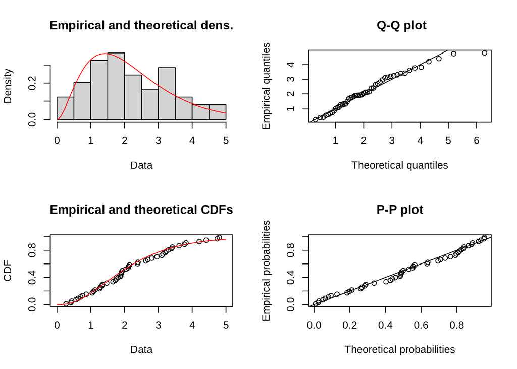

Figure 9

```r
plot(fit_g)
```

To finalize the validity of a gamma distribution, we ran an Anderson-Darling test with the null hypothesis that the observed data has no significant deviations from a gamma distribution with estimated shape parameter of 2.817178 and estimated rate parameter of 1.285045, as calculated by the fitdist() function above. The test yielded a test statistic of 0.38044 and p-value of 0.8673. At significance p = 0.05, we fail to reject the null, and there is not significant evidence that the observed data differs meaningfully from a gamma distribution with shape parameter of 2.817178 and estimated rate parameter of 1.285045. However, when running the Anderson Darling test, we encountered several warnings of NaNs introduced by the algorithm. We believed that this might be caused by some extreme values in the tails of the distribution, as can be observed by the values that fall further from the line in the Q-Q plot of Figure 9. In order to further verify the results of Anderson-Darling, we conducted a Cramer Von Mises test, which focuses less heavily on the tails of the distribution. This test yielded the same conclusion as the Anderson-Darling test (⍵<sup>2</sup> = 0.057209, p = 0.8338), so we proceeded with a gamma generalized linear model.

```r
sh <- fit_g$estimate["shape"]
ra <- fit_g$estimate["rate"]

ad_result  <- ad.test(merged_clean$avg_hatecrimes_per_100k_fbi, null = "pgamma", shape = sh, rate = ra)
cvm_result <- cvm.test(merged_clean$avg_hatecrimes_per_100k_fbi, null = "pgamma", shape = sh, rate = ra)

cat("Anderson-Darling: statistic =", round(ad_result$statistic, 5), " | p-value =", round(ad_result$p.value, 4), "\n")
```

```
Anderson-Darling: statistic = 0.38044  | p-value = 0.8673
```

```r
cat("Cramer-Von Mises: statistic =", round(cvm_result$statistic, 6), " | p-value =", round(cvm_result$p.value, 4), "\n")
```

```
Cramer-Von Mises: statistic = 0.057209  | p-value = 0.8338
```

## Fitting a Model

Before moving to fitting a model, we explored any potential for multicollinearity between predictors using a correlation matrix. Based on the correlation matrix, we concluded there was no concerning correlation between predictors. See Figure 10 for the correlation matrix.

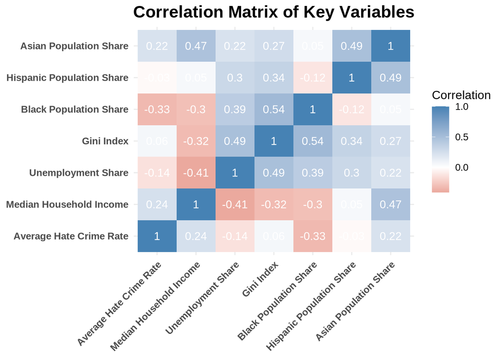

Figure 10

```r
# Select and rename variables nicely
cor_data <- merged_clean %>%
  dplyr::select(
    `Average Hate Crime Rate` = avg_hatecrimes_per_100k_fbi,
    `Median Household Income` = median_household_income,
    `Unemployment Share` = share_unemployed_seasonal,
    `Gini Index` = gini_index,
    `Black Population Share` = black_share,
    `Hispanic Population Share` = hispanic_share,
    `Asian Population Share` = asian_share
  )

# Correlation matrix
cor_matrix <- round(cor(cor_data), 2)

# Convert to long format
cor_long <- as.data.frame(as.table(cor_matrix))

# Plot
ggplot(cor_long,
       aes(x = Var1,
           y = Var2,
           fill = Freq)) +
  geom_tile() +
  geom_text(
    aes(label = Freq),
    color = "white",
    size = 4
  ) +
  scale_fill_gradient2(
    low = "firebrick",
    mid = "white",
    high = "steelblue",
    midpoint = 0
  ) +
  labs(
    title = "Correlation Matrix of Key Variables",
    x = NULL,
    y = NULL,
    fill = "Correlation"
  ) +
  theme_minimal(base_size = 12) +
  theme(
    plot.title = element_text(
      hjust = 0.5,
      face = "bold",
      size = 17
    ),
    axis.text.x = element_text(
      angle = 45,
      hjust = 1,
      face = "bold"
    ),
    axis.text.y = element_text(
      face = "bold"
    )
  )
```

After solidifying the gamma distribution as a viable choice, we fit a gamma model. We will leave a discussion and interpretation of our final model to the next section; here, we will simply illustrate our process of choosing a final model. An initial model was fit in the kitchen sink approach which included all predictors in the dataset. The results of this model showed three significant predictors at the p = 0.1 level of significance: Gini index (p = 0.017835), black share (p = 0.000742), and hispanic share (p = 0.067781). At the p = 0.05 level of significance, only Gini Index and black share were significant predictors of hate crime rate. The full results of the initial model can be observed in Figure 11.

### Figure 11. Full Gamma Model

```r
gamma_model_full <- glm(
  avg_hatecrimes_per_100k_fbi ~
    median_household_income +
    share_unemployed_seasonal +
    gini_index +
    share_population_with_high_school_degree +
    black_share +
    hispanic_share +
    asian_share +
    political_party_2012,
  family = Gamma(link = "log"),
  data = merged_clean)

stargazer(
  gamma_model_full,
  type          = "html",
  title         = "Figure 11. Full Model",
  column.labels = c("Gamma Model"),
  header        = FALSE
)
```

**Figure 11. Full Model**

|  | *Dependent variable:* |
| --- | --- |
|  | avg_hatecrimes_per_100k_fbi |
|  | Gamma Model |
| median_household_income | 0.00001 |
|  | (0.00002) |
| share_unemployed_seasonal | 1.800 |
|  | (9.354) |
| gini_index | 16.029** |
|  | (6.487) |
| share_population_with_high_school_degree | 2.267 |
|  | (5.126) |
| black_share | -0.039*** |
|  | (0.011) |
| hispanic_share | -0.019* |
|  | (0.010) |
| asian_share | 0.056 |
|  | (0.038) |
| political_party_2012Republican (Romney) | 0.134 |
|  | (0.191) |
| Constant | -8.481 |
|  | (6.212) |
| Observations | 49 |
| Log Likelihood | -68.311 |
| Akaike Inf. Crit. | 154.622 |
| *Note:* | *p<0.1; **p<0.05;*** p<0.01 |

Because the full model contained many insignificant predictors, we fit a reduced model with just the significant predictors from the full model: Gini index, black share, and hispanic share. We chose to include the hispanic share as a predictor despite its relatively low significance (p = 0.067781) in an effort to not discount any potential effects or predictors of hate crime. The reduced model yielded a significant intercept as well as significant predictors at the p = 0.1 level of significance: Gini index (p = 0.013554), black share (p = 0.000132), and hispanic share (p = 0.099718). Once again, hispanic share proved to barely be significant even at the relatively high level of p = 0.1. The AIC for this model lowered by just over 4 units, from 154.622 for the full model to 150.0011 for the reduced model. The full results from the reduced model can be seen in Figure 12.

### Figure 12. Reduced Gamma Model

```r
gamma_model_reduced <- glm(
  avg_hatecrimes_per_100k_fbi ~
    gini_index +
    black_share +
    hispanic_share,
  family = Gamma(link = "log"),
  data = merged_clean)

stargazer(
  gamma_model_reduced,
  type          = "html",
  title         = "Figure 12. Reduced Model",
  column.labels = c("Gamma Model"),
  header        = FALSE
)
```

**Figure 12. Reduced Model**

|  | *Dependent variable:* |
| --- | --- |
|  | avg_hatecrimes_per_100k_fbi |
|  | Gamma Model |
| gini_index | 13.838** |
|  | (5.385) |
| black_share | -0.039*** |
|  | (0.009) |
| hispanic_share | -0.013* |
|  | (0.008) |
| Constant | -4.911** |
|  | (2.330) |
| Observations | 49 |
| Log Likelihood | -71.001 |
| Akaike Inf. Crit. | 150.001 |
| *Note:* | *p<0.1; **p<0.05;*** p<0.01 |

We then moved to testing several combinations of interaction terms in the model, including an interaction between Gini index and political party, education and political party, and Gini index and black share. The model with an interaction between Gini index and black share yielded the lowest AIC (149.75) of each of the models up to that point in our analysis. This model contained two significant predictors at the p = 0.1 level of significance: Gini index (p = 0.00375) and hispanic share (p = 0.03998) as well as a significant intercept (p = 0.00911). The interaction model can be observed in Figure 13.

```r
# Interaction 1: Gini x Political Party
gamma_model_interaction1 <- glm(
  avg_hatecrimes_per_100k_fbi ~
    gini_index * political_party_2012 +
    black_share +
    hispanic_share,
  family = Gamma(link = "log"),
  data = merged_clean
)



# Interaction 2: Education x Political Party
gamma_model_interaction2 <- glm(
  avg_hatecrimes_per_100k_fbi ~
    share_population_with_high_school_degree * political_party_2012 +
    gini_index +
    black_share +
    hispanic_share,
  family = Gamma(link = "log"),
  data = merged_clean
)




# Interaction 3: Gini x Black Share
gamma_model_interaction3 <- glm(
  avg_hatecrimes_per_100k_fbi ~
    gini_index * black_share +
    hispanic_share,
  family = Gamma(link = "log"),
  data = merged_clean
)


stargazer(
  gamma_model_interaction3,
  type          = "html",
  title         = "Figure 13. Interaction Model (Gini x Black Share)",
  column.labels = c("Gamma Model"),
  header        = FALSE
)
```

**Figure 13. Interaction Model (Gini x Black Share)**

|  | *Dependent variable:* |
| --- | --- |
|  | avg_hatecrimes_per_100k_fbi |
|  | Gamma Model |
| gini_index | 23.533*** |
|  | (7.687) |
| black_share | 0.350 |
|  | (0.247) |
| hispanic_share | -0.017** |
|  | (0.008) |
| gini_index:black_share | -0.859 |
|  | (0.541) |
| Constant | -9.194*** |
|  | (3.370) |
| Observations | 49 |
| Log Likelihood | -69.875 |
| Akaike Inf. Crit. | 149.750 |
| *Note:* | *p<0.1; **p<0.05;*** p<0.01 |

As a final step in the model fitting process, we employed stepwise selection of predictors using the step() function to see what predictors the algorithm deemed significant based on AIC scores. This final piece of the process yielded a model with three significant predictors at the p = 0.1 level of significance: gini index (p = 0.00721), black share (p = 0.00176) and percent of population with a high school degree (p = 0.07257). The intercept is also significant (p = 0.02136).

Figure 14 summarizes the AIC scores as well as the loglikelihood values of each model we tested.

```r
gamma_model_none <- glm(
  avg_hatecrimes_per_100k_fbi ~ 1,
  family = Gamma(link = "log"),
  data   = merged_clean
)

step(gamma_model_none, direction = "forward", scope = formula(gamma_model_full))
```

```r
gamma_model_step <- glm(
  avg_hatecrimes_per_100k_fbi ~ black_share + gini_index +
    share_population_with_high_school_degree,
  family = Gamma(link = "log"),
  data   = merged_clean
)
```

### Figure 14. Model Comparison

```r
gamma_model_compare <- data.frame(
  Model = c(
    "Full Gamma Model",
    "Reduced Gamma Model",
    "Gini x Political Party",
    "Education x Political Party",
    "Gini x Black Share",
    "Stepwise Selection Model"
  ),
  AIC = c(
    AIC(gamma_model_full),
    AIC(gamma_model_reduced),
    AIC(gamma_model_interaction1),
    AIC(gamma_model_interaction2),
    AIC(gamma_model_interaction3),
    AIC(gamma_model_step)
  ),
  Log.Likelihood = c(
    round(as.numeric(logLik(gamma_model_full)), 5),
    round(as.numeric(logLik(gamma_model_reduced)), 5),
    round(as.numeric(logLik(gamma_model_interaction1)), 5),
    round(as.numeric(logLik(gamma_model_interaction2)), 5),
    round(as.numeric(logLik(gamma_model_interaction3)), 5),
    round(as.numeric(logLik(gamma_model_step)), 5)
  )
)

gamma_model_compare %>%
  mutate(AIC = round(AIC, 4)) %>%
  kbl(caption = "Figure 14. Model Comparison — AIC and Log-Likelihood") %>%
  kable_styling(full_width = FALSE, bootstrap_options = c("striped", "hover"))
```

| Model | AIC | Log.Likelihood |
| --- | --- | --- |
| Full Gamma Model | 154.6222 | -67.31112 |
| Reduced Gamma Model | 150.0011 | -70.00054 |
| Gini x Political Party | 152.9118 | -69.45589 |
| Education x Political Party | 154.2075 | -69.10373 |
| Gini x Black Share | 149.7500 | -68.87501 |
| Stepwise Selection Model | 149.4853 | -69.74267 |

Figure 11: Figure 14. Model Comparison — AIC and Log-Likelihood

## Final Model

The final model is given by equation 2 and summarized in Figure 15. In equation 1, the gamma distribution is defined by parameters (in order) shape and rate.

$$1) (Average\ Hate\ Crimes)_i \sim \text{Gamma}(2.817178,\ 1.285045)$$

$$2) \ln(\text{Average Hate Crimes per 100,000})_i = \beta_0 + \beta_1(\text{Gini Index})_i + \beta_2(\text{Share Black})_i + \beta_3(\text{Share High School Degree})_i$$

$$3) \mu_i = e^{\beta_0 + \beta_1(\text{Gini Index})_i + \beta_2(\text{Share Black})_i + \beta_3(\text{Share High School Degree})_i}$$

### Figure 15. Final Model

```r
final_gamma_model <- gamma_model_step

stargazer(
  final_gamma_model,
  type          = "html",
  title         = "Figure 15. Final Model",
  column.labels = c("Gamma Model"),
  header        = FALSE
)
```

**Figure 15. Final Model**

|  | *Dependent variable:* |
| --- | --- |
|  | avg_hatecrimes_per_100k_fbi |
|  | Gamma Model |
| black_share | -0.030*** |
|  | (0.009) |
| gini_index | 15.915*** |
|  | (5.653) |
| share_population_with_high_school_degree | 5.413* |
|  | (2.944) |
| Constant | -10.823** |
|  | (4.538) |
| Observations | 49 |
| Log Likelihood | -70.743 |
| Akaike Inf. Crit. | 149.485 |
| *Note:* | *p<0.1; **p<0.05;*** p<0.01 |

## Diagnostics

Before progressing with an interpretation for this model, we analyzed the residual plots. See Figure 16.

### Figures 16–19. Model Diagnostic Plots

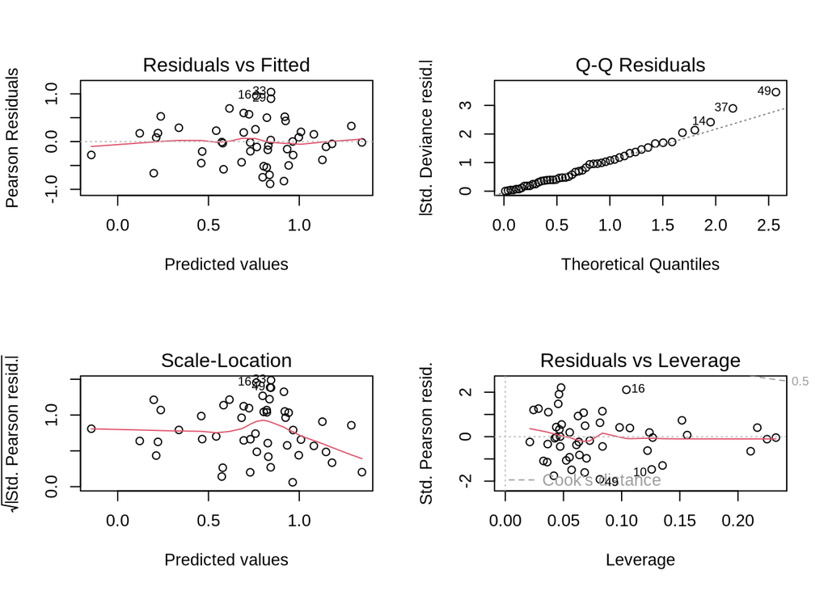

Figure 12

```r
par(mfrow = c(2, 2))
plot(final_gamma_model)
par(mfrow = c(1, 1))
```

The residuals vs. fitted plot shows a relatively straight line with relatively random scatter indicating the linearity of the data when a gamma log link is taken into account. While there does seem to be a higher density of points between 0.5 and 1, the trend line is straight, and the scatter shows no obvious cone shape, indicating linearity and equal variance throughout the model. See Figure 16 for the residuals vs. fitted plot.

The Q-Q plot is also affirming. Most points fall closely to the diagonal line. There are some mildly concerning points towards the upper right of the plot, but overall the Q-Q plot supports the efficacy of our model.

Finally, the residuals vs leverage plot indicates that there are no concerning outliers that may be skewing the regression line, as evidenced by the lack of any points close to the Cook’s distance dashed fences on the plot.

## Results

Our preferred final model examines how state-level hate crime rates are associated with income inequality (Gini Index), racial composition (specifically proportion of Black people) and level of education (proportion of the population with a high school degree). We selected this model because it provided a strong balance of explanatory power, relatively clean diagnostics, and methodological simplicity while avoiding the added uncertainty of imputing missing non-citizen share data.

In interpreting this model, we begin with the Gini index coefficient. The Gini Index has the largest substantive coefficient in the model (approximately 15.915) and is statistically significant at the 1% level (p = 0.00721). To interpret, we exponentiate the coefficient, yielding a value of 8163455. The formal interpretation concludes that a unit increase in the Gini Index is predicted to be associated with an increase in average hate crimes per 100,000 people by a factor of 8163455. Initially, this value seems outlandish, but it is important to keep in mind the scale of the Gini index. The index ranges from 0 to 1, with a score of 0 indicating perfect equality and a score of 1 indicating perfect inequality. This precise scale means that even a 0.01% increase in the Gini index leads to outsized changes in the average number of hate crimes. A theoretical increase of 1, as is the case in our formal interpretation, is only possible if the state is starting from an initial score of 0, of which there are no instances of in our dataset. As such, the initially outlandish interpretation makes more sense. In sum, increased inequality is correlated with an increase in the average number of hate crimes.

The next significant predictor is the share of Black people in each state. Black share has a coefficient of -0.029701 and is statistically significant at the 1% level (p = 0.00176). A strict interpretation of this coefficient indicates that a unit increase in the share of black people in a state is predicted to yield a 2.93% decrease in the average number of hate crimes. This means that, after controlling for inequality and other demographic shares, states with larger Black population shares tend to have lower reported hate crime rates on average. Importantly, this should not be interpreted as a direct causal relationship. Rather, Black share may be capturing broader regional, historical, or structural differences that correlate with hate crime rates. In statistical terms, this variable has stronger precision in this model than Gini, even though its substantive coefficient is numerically smaller.

The final significant predictor is the share of people with a high school degree in each state. This predictor has a coefficient of 5.412896, and is significant at the 10% level (p = 0.07257). This coefficient indicates that a unit increase in the share of people with a high school degree is predicted to be correlated with an increase in the average number of hate crimes per 100,000 people by a factor of 224.28. Put plainly, this interpretation seems a little outlandish. However, as with the Gini index, it is important to note the scale of this variable. This is also a proportion, so an increase of 0.01 is a more reasonable expected increase than a unit increase. In turn, this smaller increase of, say, 0.01, will be correlated with a more reasonable increase in the response variable, making the estimate still make sense. Additionally, it is important to note the significance of this coefficient. In statistical terms, this variable has much weaker precision in this model than the other two. Its inclusion in the model can be argued, and the questionable outsize effect that high school degree share has on average hate crime rate is reflected in that lack of precision.

## Discussion

The final model suggests that inequality and level of education are positively related to the rate of hate crime, while the proportion of Black population in each state is negatively related to hate crime. We can posit several explanations for the relationships established by the model. For one, perhaps individuals are more likely to commit hate crimes based on a perceived wealth gap, or gap in general inequality. Those who are frustrated by a lack of upward social or economic mobility, as may be the case in areas with higher inequality, may be more likely to commit violent biased crime, especially against groups they may blame for their own economic or social hardship. The positive relationship between level of education and hate has a less intuitive explanation. However, perhaps increased education is correlated with exposure to more people different from oneself, as happens at college, university, or other institutes of higher education. In turn, maybe this increased exposure introduces more groups to be biased against. In plain language, perhaps hate criminals’ biases begin in high school or college as they meet people from different backgrounds and these biases later manifest in hate crime. The proportion of Black population is a little more intuitive. The model indicates that a low Black population is related to a higher hate crime rate. In other words, the smaller the minority group, perhaps the more alienation between racial groups, the greater the social divide, and the larger the potential for increased conflict.

Some results of our model are corroborated by other literature in the area. The regression analysis “Socioeconomic Determinants of Hate Crime Rates in the US” by Zuzana Fromm of the British Columbia Institute of Technology also comes to the conclusion that hate crimes are inversely correlated with percentage of Black population (Fromm). This study uses data from 2010 to 2017, the same time frame as our data, and is segmented by state, also like our data. However, the data employed in Fromm’s study is also segmented by bias type, or in other words the motivation for the crime. Fromm employs an OLS regression model, and while we come to the same conclusion about Black population, some conclusions differ from the ones suggested by our model. The OLS model indicates that personal income and unemployment rate are found to be significant positive predictors of hate crime, while our data concluded that these predictors were not significant. Differences in conclusions likely arise from differences in modeling choices and data source.

In further exploring the conclusions from other literature, various socioeconomic factors are found to be significantly related to hate crime. Marshall Medoff’s “Allocation of Time and Hateful Behavior” also performs a regression analysis of hate crime using state data from 1995. Medoff’s OLS regression model relates higher unemployment, lower wage, and Democratic partisanship as significant, positive predictors of hate crime (Medoff, 1999). The “An Economic Analysis of Hate Crime” study also uses 1990s data, specifically statewide data across the 1992 to 1995 time frame. The authors employ a log-linear multilevel model, and find that income is significantly positively related to increased hate crime instances, and posit that higher income is an indicator of higher inequality, which in turn increases hate crimes among the less wealthy (Gale et al., 2002). This finding is consistent with our model’s conclusion that inequality is positively related to hate crime.

In addition to corroborating the results of our model, the literature introduces several theoretical economic-based frameworks in which to ground the larger context of our model. Medoff’s study introduces the so-called rational-choice framework around hate crimes. This concept introduces the classic economic idea that each person seeks to maximize their individual utility, and is constrained by external factors like time and money. In the context of hate crime, the rational-choice framework argues that performing a hate crime is a commodity that increases the utility of the criminal, and so the criminal must weigh the increase to their utility from committing the crime against the decrease in their utility from incurred punishment, like incarceration. Utility surrounding hate crimes is also influenced by socioeconomic factors in addition to punishment. For example, time spent in jail also results in the opportunity cost of foregone income, and persons who are already sensitive to changes in income may be less likely to commit a hate crime, face jail time, and forgo some of their income. Additionally, those with higher salaries forgo more income, and face a higher opportunity cost of jail time (Medoff, 1999). In our regression, we observed that increased inequality was associated with increased hate crime. The rational-choice model may support that conclusion by arguing that as inequality increases, stratification of income increases. In turn, those people with lower incomes in a high inequality situation have a lower opportunity cost of jail time, and in this sense, their cost of committing a hate crime is lower than those with higher incomes. With this logic, areas with higher inequality would be associated with an increased incidence of hate crime, as our model suggests.

The “An Economic Analysis of Hate Crime” study introduces a second economic framework: the envious behavior model. This framework follows a similar logic to the rational-choices model, but inverted. While the rational-choice model focuses on the choices a person makes to make themselves better off, the envious behavior model focuses on the choices a person makes to make another person worse off. A hate crime can be described as exactly this type of behavior: a choice the hate criminal makes to intentionally harm a victim for the sake of making that victim’s life worse. The study finds a positive significant relationship between income and hate crime, supported by our model’s positive relationship between inequality and hate crime because it is logical to assume that as income increases, income disparity also increases, which in turn increases inequality. Under the envious behavior model, members of a lower income group may be more likely to commit a hate crime against members of a higher income group in order to decrease that higher group’s well-being (Gale et al., 2002). As income inequality increases, perhaps hate crime would increase, as suggested by our model. As such, the rational-choice and envious behavior model provide theoretical foundations with which to further illuminate our model’s implications.

## Team Contributions

**Harley Nguyen:** Cleaning, compiling, and joining the data into a dataset for analysis. Performed initial EDA and visualizations. Explored the OLS model, fitting multiple models and running diagnostics.

**Jack Flugstad:** Explored the Gamma model, fitting multiple models and running diagnostics. Wrote the entirety of the research report and conducted outside research

## References

- FBI. (n.d.). Hate Crimes. Retrieved May 13, 2026, from https://www.fbi.gov/investigate/civil-rights/hate-crimes
- U.S. Department of Justice. (2025, September 24). Facts and Statistics. https://www.justice.gov/hatecrimes/hate-crime-statistics
- Fatherree, D. (2025, October 1). SPLC sees rising tide of violence as Hate Crimes Awareness Month kicks off. SPLC. https://www.splcenter.org/resources/stories/hate-crimes-awareness-month-kicks-off/
- KFF. (n.d.). About Us. Retrieved May 13, 2026, from https://www.kff.org/about-us/
- United States Census Bureau. (2024, March 25). What We Do. https://www.census.gov/about/what.html
- McDonald, M.P. (n.d.). Vita. U.S. Elections Project. Retrieved May 13, 2026, from https://www.electproject.org/vita
- SPLC. (n.d.). About. Retrieved May 13, 2026, from https://www.splcenter.org/about/
- Ford. C. (2022, October 28). Getting Started with Gamma Regression. University of Virginia | Library. https://library.virginia.edu/data/articles/getting-started-with-gamma-regression
- Lieberman, M. (2025, October 17). Hate Crimes, Explained. SPLC. https://www.splcenter.org/resources/reports/hate-crimes-explained/
- fivethirtyeight. (2016). data[hate_crimes.csv]. fivethirtyeight. https://github.com/fivethirtyeight/data/blob/master/hate-crimes/README.md
- MIT Election Data and Science Lab, 2017, U.S. President 1976–2020, https://doi.org/10.7910/DVN/42MVDX, Harvard Dataverse, V8; 1976-2020-president.tab [1976-2020-president.tab], UNF:6:a2yzwWNbv+Eff8aqVmkZKA== [fileUNF]
- Whitcomb, R., Choi, J.M., Guan, Bo. (2021, November 5). CORGIS (Version 3.0.0) [State Demographics]. CORGIS. https://corgis-edu.github.io/corgis/csv/state_demographics/
- Medoff, M.H. (1999), Allocation of Time and Hateful Behavior. American Journal of Economics and Sociology, 58: 959-973. https://doi.org/10.1111/j.1536-7150.1999.tb03403.x
- Gale, L. R., Heath, W. C., & Ressler, R. W. (2002). An Economic Analysis of Hate Crime. Eastern Economic Journal, 28(2), 203–216. http://www.jstor.org/stable/40326097
- Fromm, Z. (n.d.) Socioeconomic Determinants of Hate Crime Rates in the US. ResearchGate. https://www.researchgate.net/publication/340491943_SOCIOECONOMIC_DETERMINANTS_OF_HATE_CRIME_RATES_IN_THE_US